# Problem Set 3

Bailey Kretzler & Sarah Morris

10/5/2020

In teams of two, address the following questions:

What species (and location if available) did you choose? Why did you choose the species? What question do you want to answer about this population (e.g. population status, best management strategies)? Calculate eigenvalue, stable age distribution, elasticity, and sensitivity. What does this tell you about the population? Using the calculations in part (c), or additional calculations, address the question you proposed in part (b).

**(a)**

We selected the species *Phaseoulus lunatus*, commonly known as lima bean, in part because it is a food crop but also because of interesting features in the matrix. The matrix describes a threatened wild population of lima bean in Costa Rica. This population is a valuable genetic resource for biodiversity conservation and varietal improvement in other beans.

**(b)**

Within the matrix, it is clear that lima beans have strong seed dormancy. Therefore, it would be interesting to follow the trajectory of the associated paper and examine how seed dormancy impacts survival and growth. Specifically, if we decrease seed dormancy and increase seed germination, what happens to species survival in terms of the eigen value? These changes would be reflected in the matrix by increasing the rate at which individuals move from stage G<sub>0</sub> to L<sub>1</sub> and proportionally decreasing the number of individuals moving from G<sub>0</sub> to G<sub>1</sub>.

```r
# creating the matrix
data<- c(0,0.16,0.12,0.08,0,0,0,0,0.14,0.09,0,0,0,0,0,0.01,0,0,0.42,0,0,0.01,0.05,0,28.9,0,0,0,0.16,0.18,104,0,0,0,0,0.25) #data in matrix by column

Phasmat<- matrix(data = data, nrow = 6, ncol =  6) #creating matrix and inputting above data

colnames(Phasmat) = c("G0", "G1", "J", "L1", "L2", "L3") #assigning the life stage IDs to the column names

Phasmat #viewing matrix
```

```
##        G0   G1    J   L1    L2     L3
## [1,] 0.00 0.00 0.00 0.42 28.90 104.00
## [2,] 0.16 0.00 0.00 0.00  0.00   0.00
## [3,] 0.12 0.14 0.00 0.00  0.00   0.00
## [4,] 0.08 0.09 0.01 0.01  0.00   0.00
## [5,] 0.00 0.00 0.00 0.05  0.16   0.00
## [6,] 0.00 0.00 0.00 0.00  0.18   0.25
```

```r
L <- Phasmat # reassigning matrix to object L for leslie matrix
```

In lieu of extracting the matrix from the website, we created the matrix here.

```r
require(tidyr)
t = 50 # setting time = to 50
Nt = matrix(nrow = nrow(L), ncol = t+1 , data = 0) # creating an initial population matrix


Nt[,1] = 50 #where all life stages are at size 50 in year 1
Nt #checking Nt
```

```
##      [,1] [,2] [,3] [,4] [,5] [,6] [,7] [,8] [,9] [,10] [,11] [,12] [,13] [,14]
## [1,]   50    0    0    0    0    0    0    0    0     0     0     0     0     0
## [2,]   50    0    0    0    0    0    0    0    0     0     0     0     0     0
## [3,]   50    0    0    0    0    0    0    0    0     0     0     0     0     0
## [4,]   50    0    0    0    0    0    0    0    0     0     0     0     0     0
## [5,]   50    0    0    0    0    0    0    0    0     0     0     0     0     0
## [6,]   50    0    0    0    0    0    0    0    0     0     0     0     0     0
##      [,15] [,16] [,17] [,18] [,19] [,20] [,21] [,22] [,23] [,24] [,25] [,26]
## [1,]     0     0     0     0     0     0     0     0     0     0     0     0
## [2,]     0     0     0     0     0     0     0     0     0     0     0     0
## [3,]     0     0     0     0     0     0     0     0     0     0     0     0
## [4,]     0     0     0     0     0     0     0     0     0     0     0     0
## [5,]     0     0     0     0     0     0     0     0     0     0     0     0
## [6,]     0     0     0     0     0     0     0     0     0     0     0     0
##      [,27] [,28] [,29] [,30] [,31] [,32] [,33] [,34] [,35] [,36] [,37] [,38]
```

[output cut: 20 more lines]

```r
L # as defined above
```

```
##        G0   G1    J   L1    L2     L3
## [1,] 0.00 0.00 0.00 0.42 28.90 104.00
## [2,] 0.16 0.00 0.00 0.00  0.00   0.00
## [3,] 0.12 0.14 0.00 0.00  0.00   0.00
## [4,] 0.08 0.09 0.01 0.01  0.00   0.00
## [5,] 0.00 0.00 0.00 0.05  0.16   0.00
## [6,] 0.00 0.00 0.00 0.00  0.18   0.25
```

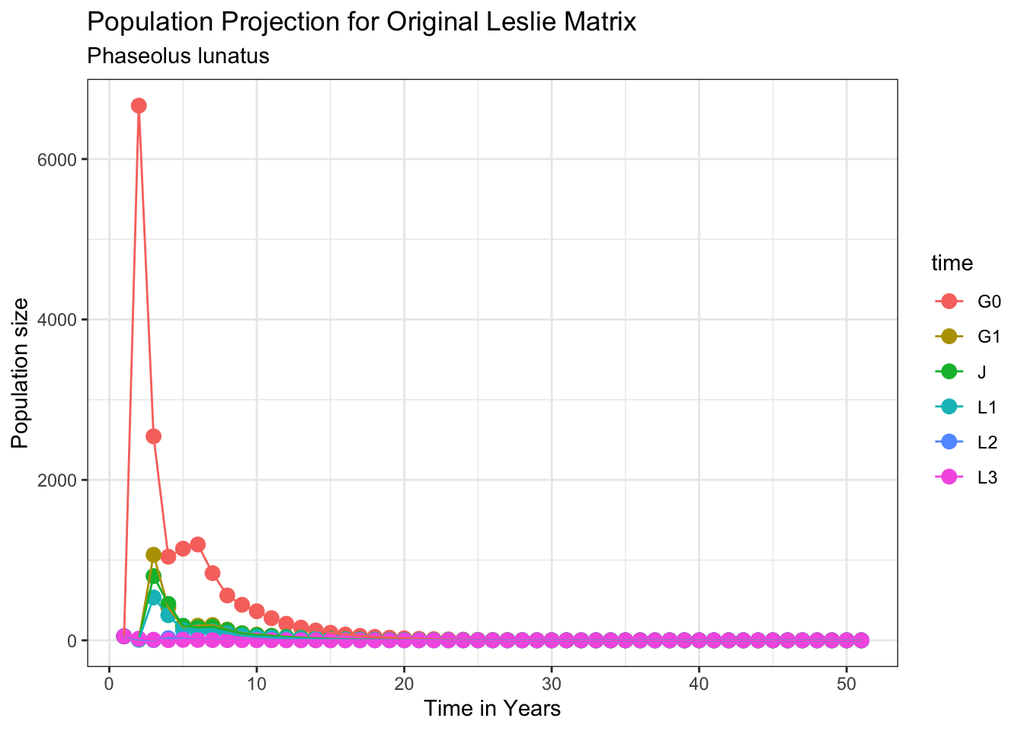

```r
#for loop to determine the size of each life stage across 50 years
for (i in 1:t)
{
    Nt[, i + 1] <- L %*% Nt[,i]
}

Pop <- t(Nt)

time =c(1:51)
Pop_time <- as.data.frame(cbind(Pop, time))
colnames(Pop_time) = c("G0", "G1", "J", "L1", "L2", "L3", "time")
Pop_time <- gather(Pop_time, key = "time", value = "pop")
repeat_t =c(c(1:51),c(1:51),c(1:51),c(1:51),c(1:51),c(1:51))
Pop_time <- cbind(Pop_time, repeat_t)

require(ggplot2)
ggplot(data = Pop_time, aes(x = repeat_t, y = pop, colour = time)) + geom_point(size = 3) + theme_bw() + geom_line() + ggtitle("Population Projection for Original Leslie Matrix", subtitle = "Phaseolus lunatus") +labs(x = "Time in Years", y = "Population size" )
```

So why is this the case? What do the eigenvalues and vectors look like?

```r
require(popbio)
Lima_eigen <-eigen(L) # using eigen function to find vectors and values

Lima_eigen
```

```
## eigen() decomposition
## $values
## [1]  0.7675902+0.0000000i  0.0343571+0.5053373i  0.0343571-0.5053373i
## [4] -0.2003484+0.0545276i -0.2003484-0.0545276i -0.0156077+0.0000000i
##
## $vectors
##                [,1]                      [,2]                      [,3]
## [1,] 0.953885394+0i  0.914342325+0.000000000i  0.914342325+0.000000000i
## [2,] 0.198832211+0i  0.019592056-0.288167201i  0.019592056+0.288167201i
## [3,] 0.185388962+0i -0.064405901-0.226931123i -0.064405901+0.226931123i
## [4,] 0.126796276+0i -0.048616341-0.149307722i -0.048616341+0.149307722i
## [5,] 0.010434358+0i -0.012786644+0.007989451i -0.012786644-0.007989451i
## [6,] 0.003628709+0i  0.004051606+0.002825629i  0.004051606-0.002825629i
##                           [,4]                      [,5]             [,6]
## [1,]  0.783811124+0.000000000i  0.783811124+0.000000000i -1.177959e-02+0i
## [2,] -0.582789490-0.158614122i -0.582789490+0.158614122i  1.207567e-01+0i
## [3,] -0.086019649+0.087425387i -0.086019649-0.087425387i -9.926122e-01+0i
## [4,] -0.057320600+0.048849743i -0.057320600-0.048849743i  1.499751e-05+0i
## [5,]  0.008778159-0.005449825i  0.008778159+0.005449825i -4.270173e-06+0i
## [6,] -0.003717783+0.001728099i -0.003717783-0.001728099i  2.893859e-06+0i
```

```r
elasticity(L)
```

```
##               G0           G1           J         L1         L2         L3
## [1,] 0.000000000 0.0000000000 0.000000000 0.01749064 0.09904065 0.12394682
## [2,] 0.045706411 0.0000000000 0.000000000 0.00000000 0.00000000 0.00000000
## [3,] 0.003733212 0.0009078624 0.000000000 0.00000000 0.00000000 0.00000000
## [4,] 0.191038489 0.0447985482 0.004641075 0.00317425 0.00000000 0.00000000
## [5,] 0.000000000 0.0000000000 0.000000000 0.22298747 0.05872049 0.00000000
## [6,] 0.000000000 0.0000000000 0.000000000 0.00000000 0.12394682 0.05986725
```

```r
sensitivity(L)
```

```
##               G0           G1           J         L1           L2           L3
## [1,]  0.24047811  0.050126352 0.046737258 0.03196582 0.0026305410 9.148113e-04
## [2,]  0.21927372  0.045706411 0.042616154 0.02914720 0.0023985904 8.341469e-04
## [3,]  0.02387981  0.004977616 0.004641075 0.00317425 0.0002612164 9.084203e-05
## [4,]  1.83299099  0.382076979 0.356244365 0.24365236 0.0200507142 6.972946e-03
## [5,] 25.75310524  5.368094403 5.005152066 3.42326012 0.2817079613 9.796830e-02
## [6,] 48.31954325 10.071945394 9.390970895 6.42292896 0.5285576203 1.838141e-01
```

```r
#our numbers are slightly different from paper - why?
eigen.analysis(L) #another way to visualize the eigen value, eigen vector, sensitivity matrix & elasticity matrix
```

```
## $lambda1
## [1] 0.7675902
##
## $stable.stage
## [1] 0.644967804 0.134440023 0.125350396 0.085733062 0.007055171 0.002453545
##
## $sensitivities
##               G0           G1           J         L1           L2           L3
## [1,]  0.24047811  0.050126352 0.046737258 0.03196582 0.0026305410 9.148113e-04
## [2,]  0.21927372  0.045706411 0.042616154 0.02914720 0.0023985904 8.341469e-04
## [3,]  0.02387981  0.004977616 0.004641075 0.00317425 0.0002612164 9.084203e-05
## [4,]  1.83299099  0.382076979 0.356244365 0.24365236 0.0200507142 6.972946e-03
## [5,] 25.75310524  5.368094403 5.005152066 3.42326012 0.2817079613 9.796830e-02
## [6,] 48.31954325 10.071945394 9.390970895 6.42292896 0.5285576203 1.838141e-01
##
## $elasticities
##               G0           G1           J         L1         L2         L3
## [1,] 0.000000000 0.0000000000 0.000000000 0.01749064 0.09904065 0.12394682
## [2,] 0.045706411 0.0000000000 0.000000000 0.00000000 0.00000000 0.00000000
## [3,] 0.003733212 0.0009078624 0.000000000 0.00000000 0.00000000 0.00000000
## [4,] 0.191038489 0.0447985482 0.004641075 0.00317425 0.00000000 0.00000000
## [5,] 0.000000000 0.0000000000 0.000000000 0.22298747 0.05872049 0.00000000
## [6,] 0.000000000 0.0000000000 0.000000000 0.00000000 0.12394682 0.05986725
##
## $repro.value
## [1]   1.00000000   0.91182400   0.09930139   7.62227783 107.09126489
## [6] 200.93114822
##
## $damping.ratio
## [1] 1.515479
```

Note from bailey to sarah: Ok, so from here i think it is useful to maybe just change the matrix above like we talked about and then run the analysis again and make another graph to have a visual comparison. I am still kinda sure exactly how the sensitivity analysis/calculation works. Maybe need to spend more time with the site i sent you.. also unsure what the above outputs mean..I agree!